# CE Assignment 1

# c) Are any of the predictors associated with per capita crime rate? If so, explain the relationship

chas seems to be associated with crim. High crime rates are concentrated in areas that do NOT bound the Charles River.

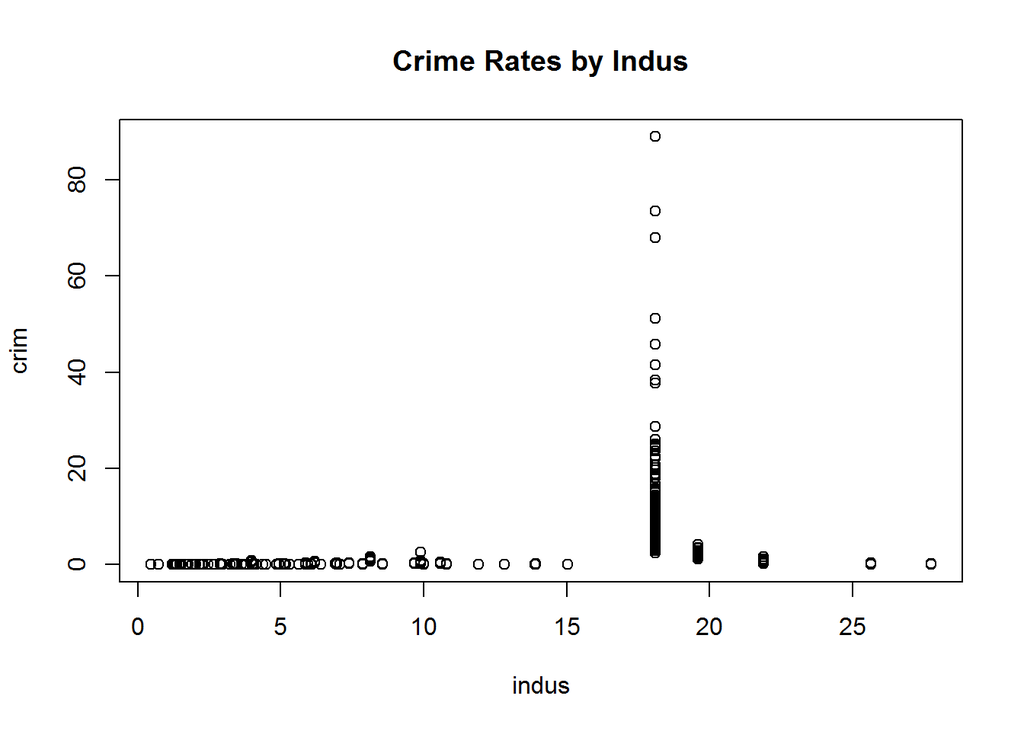

```r
plot(indus,crim, main = "Crime Rates by Indus")
```

indus at first does not appear to be associated with crim, but at around 18 non-retail business acres, crime rate is especially high. Perhaps these 18 business acres are concentrated in specific high-crime areas in Boston.

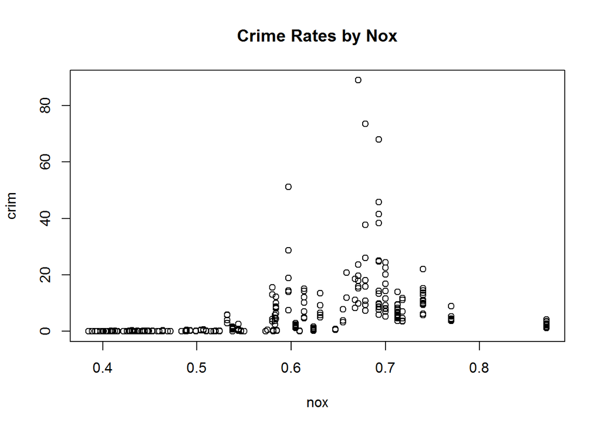

```r
plot(nox,crim, main = "Crime Rates by Nox")
```

nox appears to be associated with crim. The higher the concentration of nitric oxide, the higher the crime rates, with the center of the distribution at around 0.7.

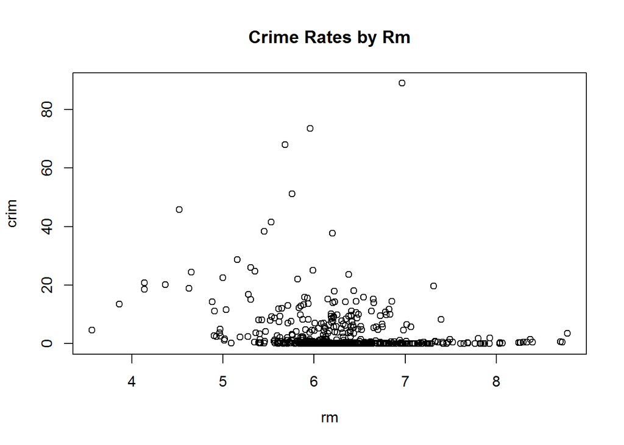

```r
plot(rm, crim, main = "Crime Rates by Rm")
```

rm does NOT seem to be associated with crim. Both low and high crime rates can be found in both low and high average rooms per house, and the data distribution does not appear to follow a particular pattern.

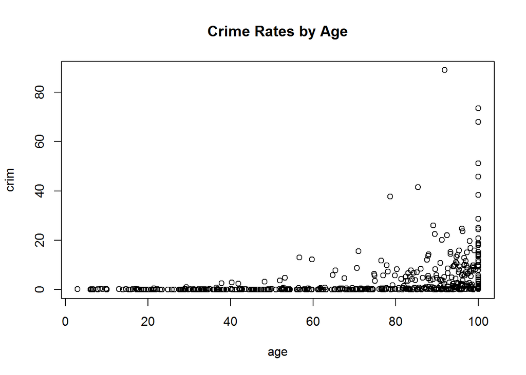

```r
plot(age, crim, main = "Crime Rates by Age")
```

age seems to be associated with crim, with the majority of crime concentrated around areas of high proportion of pre-1940 houses, which suggests that high crime rates are associated with older neighborhoods.

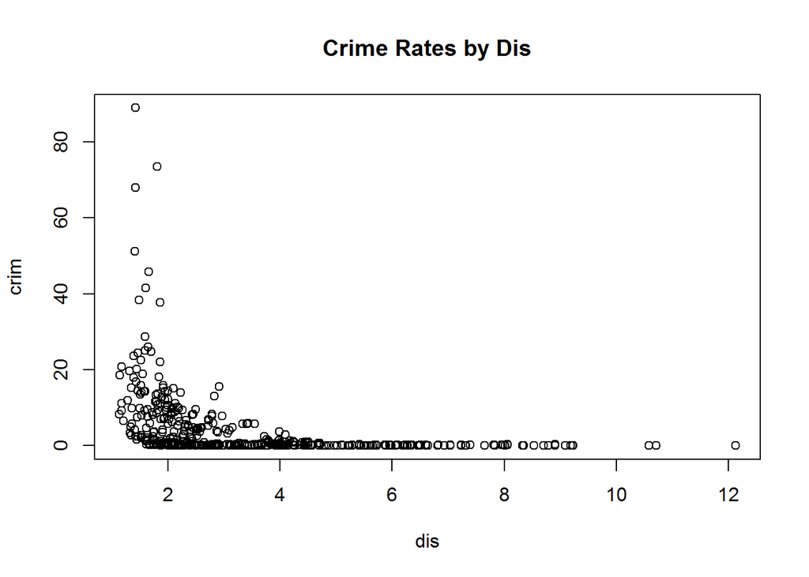

```r
plot(dis, crim, main = "Crime Rates by Dis")
```

dis seems to be associated with crim, with the high crime rates concentrated around lower distances from city centers. This suggests that the closer an area is to city centers, the higher the crime rate.

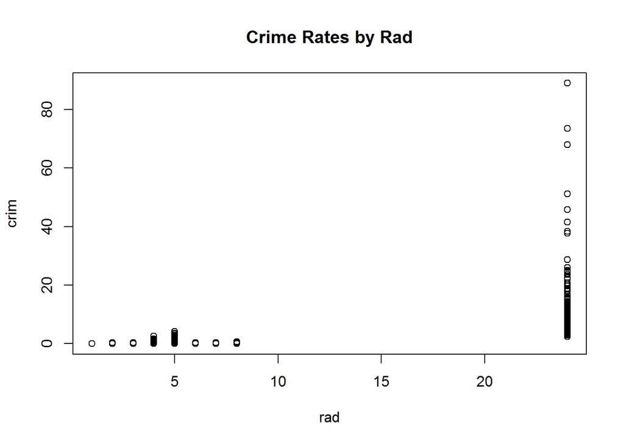

```r
plot(rad, crim, main = "Crime Rates by Rad")
```

rad seems to be associated with crim. High crime rates are concentrated around the highest index of radial highways, suggesting that crime rates are highest when most accessible to central highways of a city.

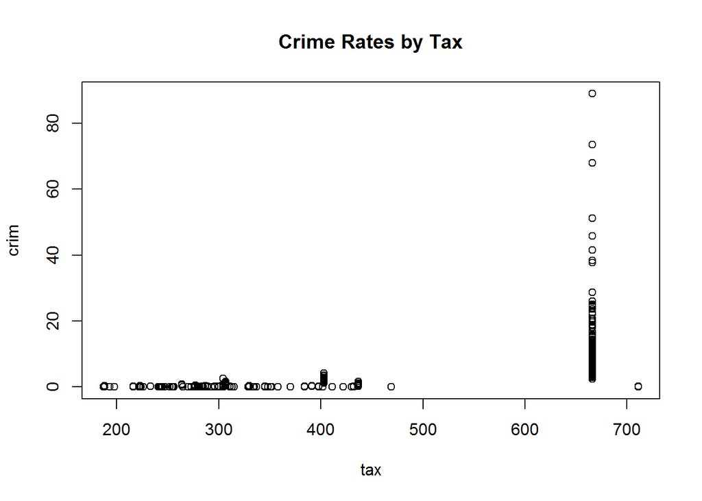

```r
plot(tax, crim, main = "Crime Rates by Tax")
```

tax seems to be associated with crim, though the crime rates are concentrated around one high tax rate over the others.

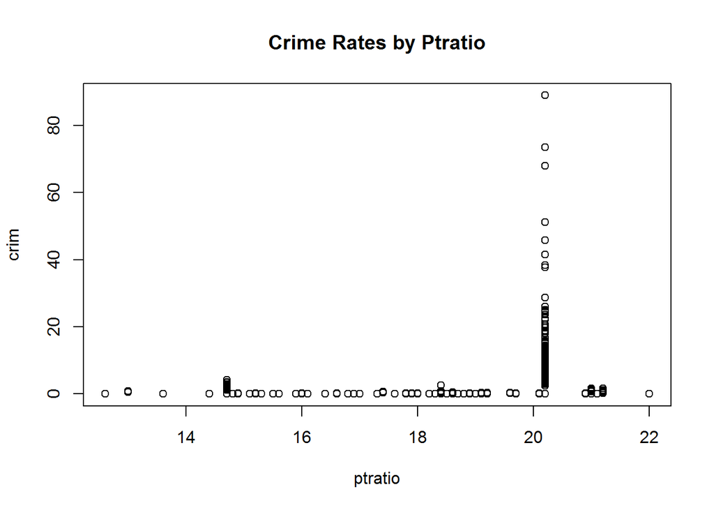

```r
plot(ptratio, crim, main = "Crime Rates by Ptratio")
```

most of the crime rates are concentrated around one HIGH ptratio, suggesting that areas with either a high volume of students or low volume of teachers have higher crime rates. However, the high crime rates are not widely spread, with the high crime rates concentrated around one specific ptratio.

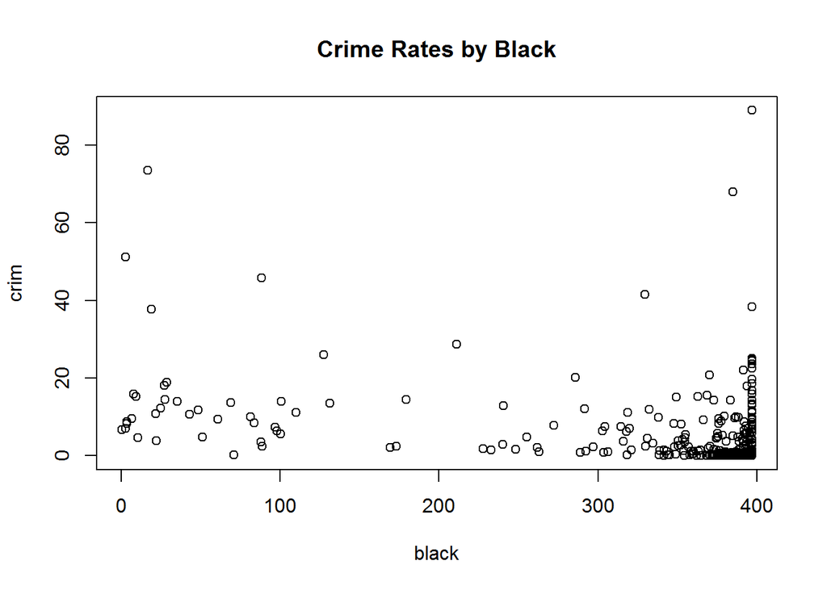

```r
plot(black, crim, main = "Crime Rates by Black")
```

black does not seem to be highly correlated with crim. Most of the values of crime rate per capita are concentrated in suburbs of higher black populations, but the high crime rates per capita are scattered even in low black populations.

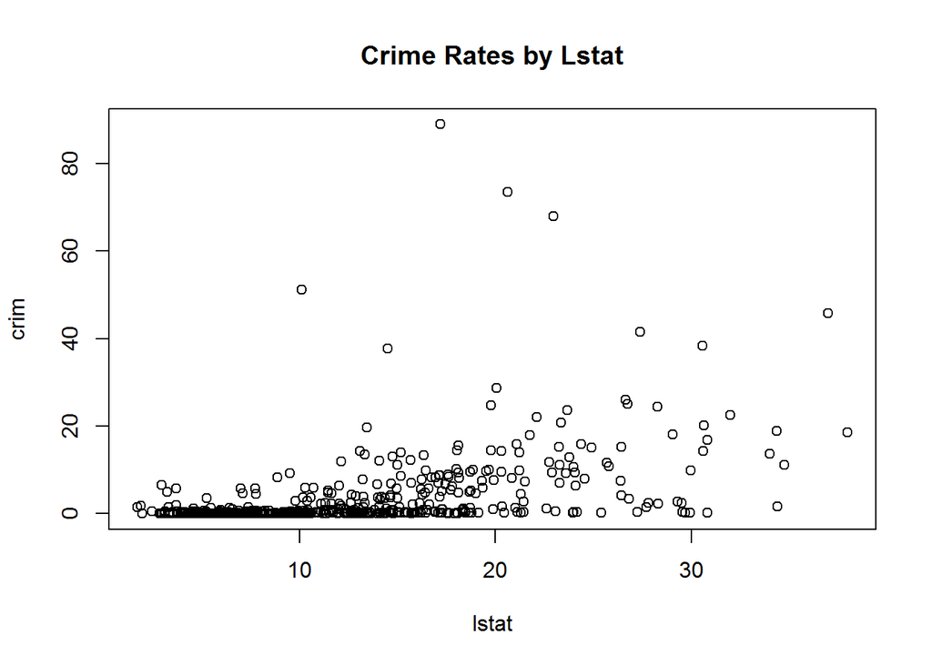

```r
plot(lstat, crim, main = "Crime Rates by Lstat")
```

lstat seems to be slightly associated with crim. As the percentage of lower status goes up, the crime rate per capita goes up.

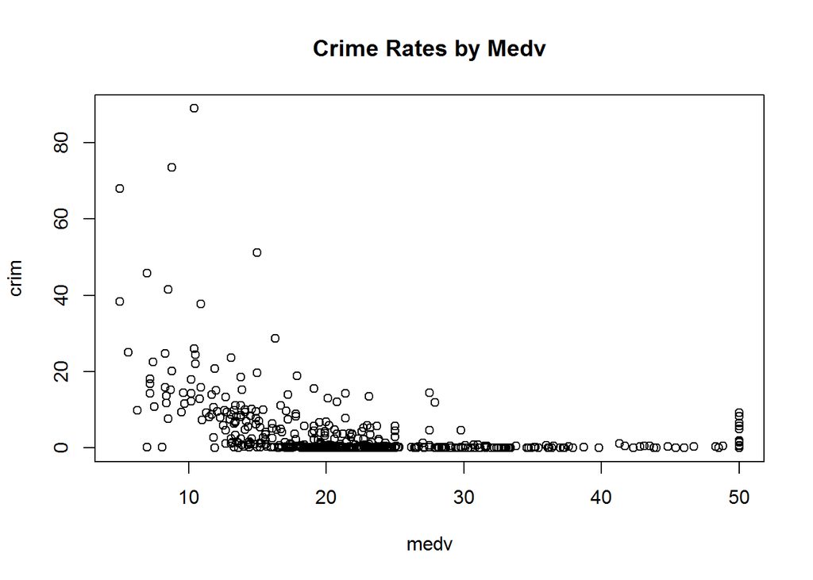

```r
plot(medv, crim, main = "Crime Rates by Medv")
```

medv seems to be associated with crim. The lower the median value of homes of a suburb, the higher the crime rates.